# project

Eric Friesth, Aashwin Lamsal, Ethan Wanlass

11/21/2019

## Gun Violence incidences recorded in the US from 2013 to 2018

### Background

#### This project analyzes the geographic and demographic data collected on incidences of gun violence around the United States from January 2013 til March 2018. This dataset was compiled on Kaggle after the Parkland Shooting in February 2018 and its purpose was to draw insights and hopefully predictions from these past ocurrances of gun violence.

### Data Cleaning

```r
#Initial cleaning was done using MS Excel, we dropped columns that we weren't planning to use (Address, house district, senate district, part2-5_age) and removed rows with empty cells.
data = read.csv('gun-violence-202.csv')
head(data)
```

```
##   ï..incident_id       date        state  city_or_county latitude
## 1              1  7/25/2016 Pennsylvania    Philadelphia  39.9252
## 2              2  10/4/2017   California Shingle Springs  38.6658
## 3              3 12/21/2014     Michigan         Detroit  42.3303
## 4              4   6/2/2016     Missouri     Saint Louis  38.7455
## 5              5   6/4/2017    Tennessee         Memphis  35.0394
## 6              6  7/28/2016        Texas     San Antonio  29.5249
##   longitude congressional_district n_killed n_injured part1_age
## 1  -75.1476                      1        0         0        17
## 2 -120.9260                      4        1         1        28
## 3  -83.0412                     14        0         2        29
## 4  -90.2448                      1        1         0        18
## 5  -90.0925                      9        1         0        30
## 6  -98.5577                     20        0         1        42
##   n_adult_part n_teen_part n_child_part n_male_part n_female_part
## 1            1           1            0           2             0
## 2            2           0            0           1             1
## 3            3           0            0           3             0
## 4            1           0            0           1             0
## 5            1           0            0           1             0
## 6            2           0            0           2             0
##   n_part_arrested n_part_killed n_part_injured
## 1               0             0              0
## 2               0             1              1
## 3               0             0              2
## 4               0             1              0
## 5               0             1              0
## 6               1             0              1
```

```r
str(data)
```

```
## 'data.frame':    226236 obs. of  18 variables:
##  $ ï..incident_id        : int  1 2 3 4 5 6 7 8 9 10 ...
##  $ date                  : Factor w/ 1561 levels "","1/1/2014",..: 1260 258 454 1114 1168 1272 500 1426 1381 493 ...
##  $ state                 : Factor w/ 52 levels "","Alabama","Alaska",..: 40 6 24 27 44 45 33 37 45 11 ...
##  $ city_or_county        : Factor w/ 2805 levels "","Abbotsford",..: 1942 2320 629 2182 1559 2213 2150 461 72 846 ...
##  $ latitude              : num  39.9 38.7 42.3 38.7 35 ...
##  $ longitude             : num  -75.1 -120.9 -83 -90.2 -90.1 ...
##  $ congressional_district: int  1 4 14 1 9 20 2 11 6 18 ...
##  $ n_killed              : int  0 1 0 1 1 0 2 0 0 0 ...
##  $ n_injured             : int  0 1 2 0 0 1 0 1 1 0 ...
##  $ part1_age             : Factor w/ 97 levels "","0","0:00",..: 12 24 25 13 27 40 36 11 14 27 ...
##  $ n_adult_part          : int  1 2 3 1 1 2 2 0 3 1 ...
##  $ n_teen_part           : int  1 0 0 0 0 0 0 1 0 0 ...
##  $ n_child_part          : int  0 0 0 0 0 0 0 0 0 0 ...
##  $ n_male_part           : int  2 1 3 1 1 2 2 1 2 1 ...
##  $ n_female_part         : int  0 1 0 0 0 0 0 0 1 0 ...
##  $ n_part_arrested       : int  0 0 0 0 0 1 0 0 1 1 ...
##  $ n_part_killed         : int  0 1 0 1 1 0 2 0 0 0 ...
##  $ n_part_injured        : int  0 1 2 0 0 1 0 1 1 0 ...
```

```r
#Changing data type for date from factor to date

data$date <- as.Date(data$date, format = "%m/%d/%Y")
#head(data)
#Date format is in YYYY-MM-DD

#Changing the data type for age from factor to int
data$part1_age <- as.integer(data$part1_age)
#head(data)
#str(data)

#Next, we drop rows with NA values using na.omit.

data_clean <- na.omit(data)

# Finally, we noticed in our two factor variables, state and city_or_county, had levels "" (empty strings) that had to be removed as they were unwanted.

# We did this using the following code to drop levels.

data_clean$state[data_clean$state == ""] = NA
data_clean$state = droplevels(data_clean$state)

data_clean$city_or_county[data_clean$city_or_county == ""] = NA
data_clean$city_or_county = droplevels(data_clean$city_or_county)

# Extracted the year and month from the date to be used for more analysis

data_clean$year = substring(data_clean$date, 1, 4)

data_clean$month = substring(data_clean$date, 6, 7)

#changing the data types from characters to numeric

data_clean$year <- as.numeric(data_clean$year)
data_clean$month <- as.numeric(data_clean$month)

# Final view of cleaned data

head(data_clean)
```

```
##   ï..incident_id       date        state  city_or_county latitude
## 1              1 2016-07-25 Pennsylvania    Philadelphia  39.9252
## 2              2 2017-10-04   California Shingle Springs  38.6658
## 3              3 2014-12-21     Michigan         Detroit  42.3303
## 4              4 2016-06-02     Missouri     Saint Louis  38.7455
## 5              5 2017-06-04    Tennessee         Memphis  35.0394
## 6              6 2016-07-28        Texas     San Antonio  29.5249
##   longitude congressional_district n_killed n_injured part1_age
## 1  -75.1476                      1        0         0        12
## 2 -120.9260                      4        1         1        24
## 3  -83.0412                     14        0         2        25
## 4  -90.2448                      1        1         0        13
## 5  -90.0925                      9        1         0        27
## 6  -98.5577                     20        0         1        40
##   n_adult_part n_teen_part n_child_part n_male_part n_female_part
## 1            1           1            0           2             0
## 2            2           0            0           1             1
## 3            3           0            0           3             0
## 4            1           0            0           1             0
## 5            1           0            0           1             0
## 6            2           0            0           2             0
##   n_part_arrested n_part_killed n_part_injured year month
## 1               0             0              0 2016     7
## 2               0             1              1 2017    10
## 3               0             0              2 2014    12
## 4               0             1              0 2016     6
## 5               0             1              0 2017     6
## 6               1             0              1 2016     7
```

```r
str(data_clean)
```

```
## 'data.frame':    10735 obs. of  20 variables:
##  $ ï..incident_id        : int  1 2 3 4 5 6 7 8 9 10 ...
##  $ date                  : Date, format: "2016-07-25" "2017-10-04" ...
##  $ state                 : Factor w/ 51 levels "Alabama","Alaska",..: 39 5 23 26 43 44 32 36 44 10 ...
##  $ city_or_county        : Factor w/ 2804 levels "Abbotsford","Aberdeen",..: 1941 2319 628 2181 1558 2212 2149 460 71 845 ...
##  $ latitude              : num  39.9 38.7 42.3 38.7 35 ...
##  $ longitude             : num  -75.1 -120.9 -83 -90.2 -90.1 ...
##  $ congressional_district: int  1 4 14 1 9 20 2 11 6 18 ...
##  $ n_killed              : int  0 1 0 1 1 0 2 0 0 0 ...
##  $ n_injured             : int  0 1 2 0 0 1 0 1 1 0 ...
##  $ part1_age             : int  12 24 25 13 27 40 36 11 14 27 ...
##  $ n_adult_part          : int  1 2 3 1 1 2 2 0 3 1 ...
##  $ n_teen_part           : int  1 0 0 0 0 0 0 1 0 0 ...
##  $ n_child_part          : int  0 0 0 0 0 0 0 0 0 0 ...
##  $ n_male_part           : int  2 1 3 1 1 2 2 1 2 1 ...
##  $ n_female_part         : int  0 1 0 0 0 0 0 0 1 0 ...
##  $ n_part_arrested       : int  0 0 0 0 0 1 0 0 1 1 ...
##  $ n_part_killed         : int  0 1 0 1 1 0 2 0 0 0 ...
##  $ n_part_injured        : int  0 1 2 0 0 1 0 1 1 0 ...
##  $ year                  : num  2016 2017 2014 2016 2017 ...
##  $ month                 : num  7 10 12 6 6 7 12 8 8 12 ...
##  - attr(*, "na.action")= 'omit' Named int  10736 10737 10738 10739 10740 10741 10742 10743 10744 10745 ...
##   ..- attr(*, "names")= chr  "10736" "10737" "10738" "10739" ...
```

## Data Exploration

The population data was gathered from the U.S. Census Bureau, taken from https://www.census.gov/data/tables/time-series/demo/popest/2010s-state-total.html. In this data set we deleted the unnecessary rows (regions and Puerto Rico) as well as Columns not in use. Additionally, the column for the states was called named, so it was renamed to state to match that of the kaggle set.

## Data Exploration continued

### Number of Incidents per State

One of our interests in this data set was finding the states with the most incidents and seeing in those states where those incidents were occurring. Since, we’re using a sample of a sample, the results will not be the direct number of those incidents, but it is proportional. To find this, a graph ranking the states from the most incidents to least incidents was made.

[figure not shown]

Looking at the figure, we see that Illinois, California and Florida have the top three number of incidents. Basing code from Randy Lai from https://stackoverflow.com/questions/23206834/how-to-plot-a-us-state-in-r , we created the plots of those incidents for Illinois, California and Florida, although only Illinois will be shown below.

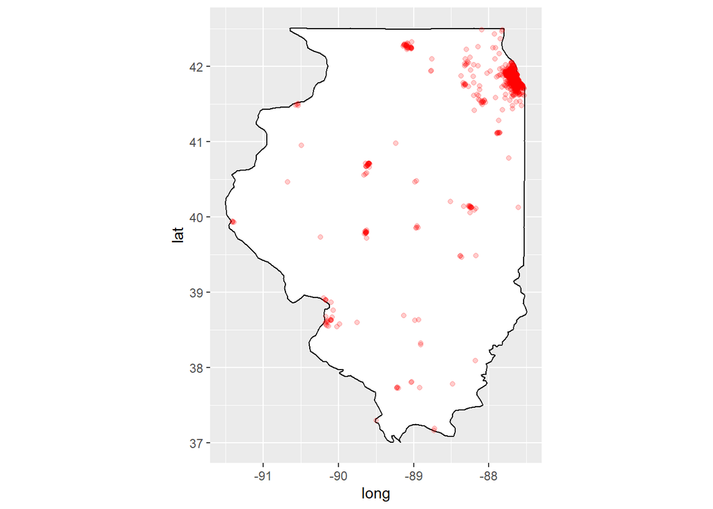

The incidents for each of these states are mostly occurring around the major cities in that State. For Illinois, most of the incidents are in the upper right of the state where chicago. For California, the major hotspots are around their coastal cities: San Francisco, Los Angeles and San Diego. For Florida, the major hotspots are around Miami, Orlando, Tampa and Jacksonville. Thus, it appears that the metropolitan areas have the most incidents.

Another factor to consider is the influence of population into these incidents. Illinois, California and Florida all have high state population in the U.S., so we wanted to see the relation of population to the number of incidents.

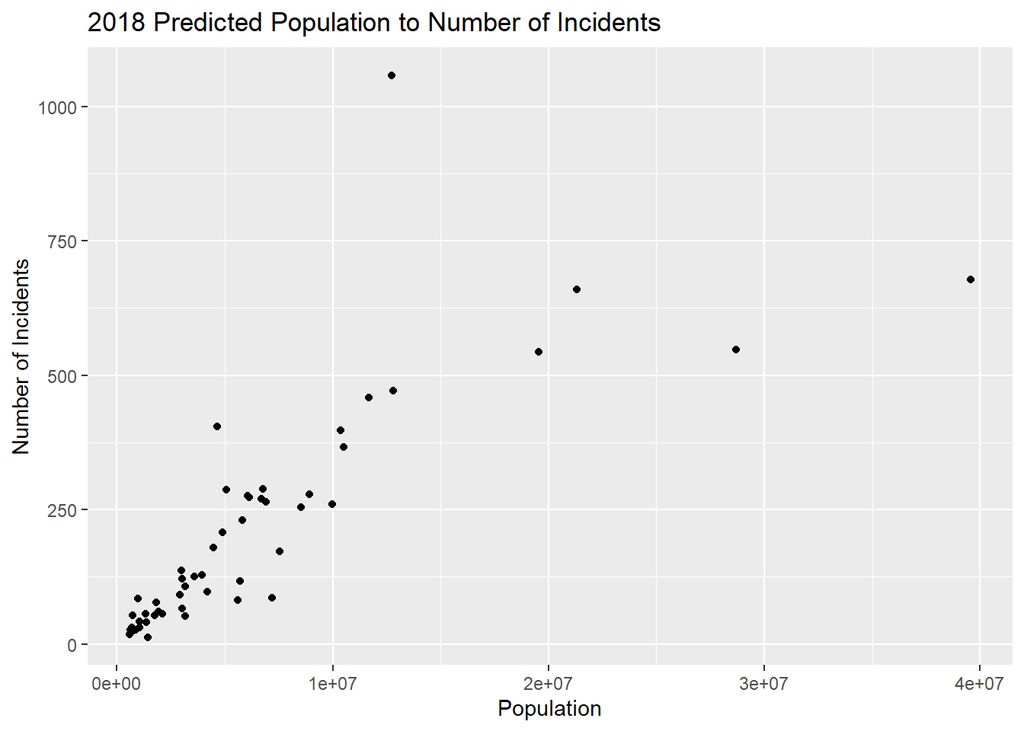

Looking at the plot, one can see there is a moderate to strong positive relation between the two. Thus, we’d like to compare the number of incidents per capita, using the predicted population for 2018, to see if there’s any change from before. Similarly, the per capita numbers are not going to be exact, but should be proportional.

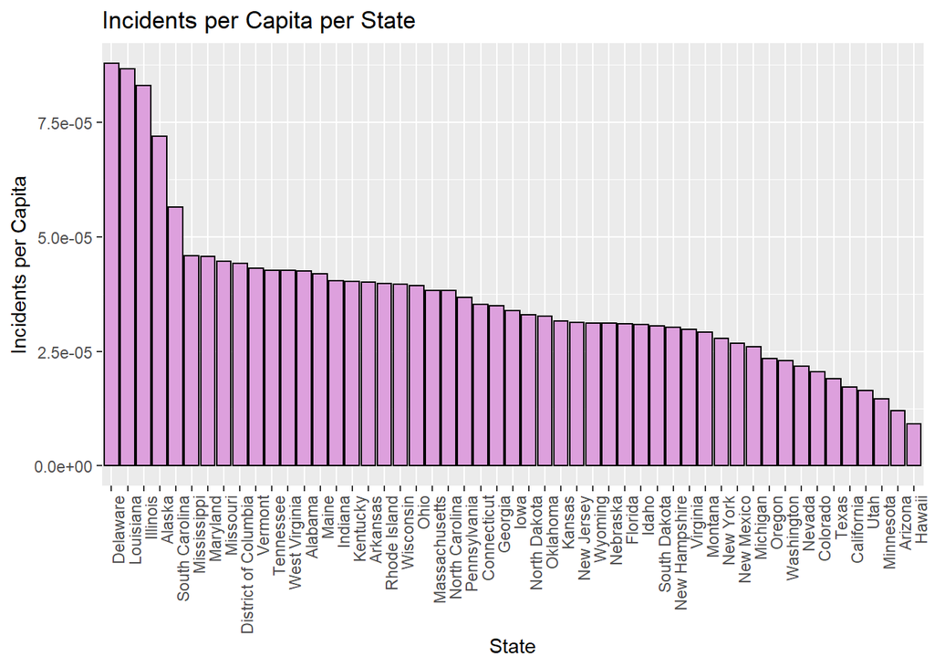

## Data Visualization

### Heatmap

#### Our heatmap is saved in our github repo as ‘data_clean.png’ (you’ll need to change the name and file location/path in “ggsave()” in the code block which is commented out at the moment)

```r
# Scatter Pair plot:

# pairs(data_clean[ ,7:18], pch = 19, lower.panel = NULL)
```

[figure not shown]

### Distribution of Gun Violence Incidents over Time (2013-2018)

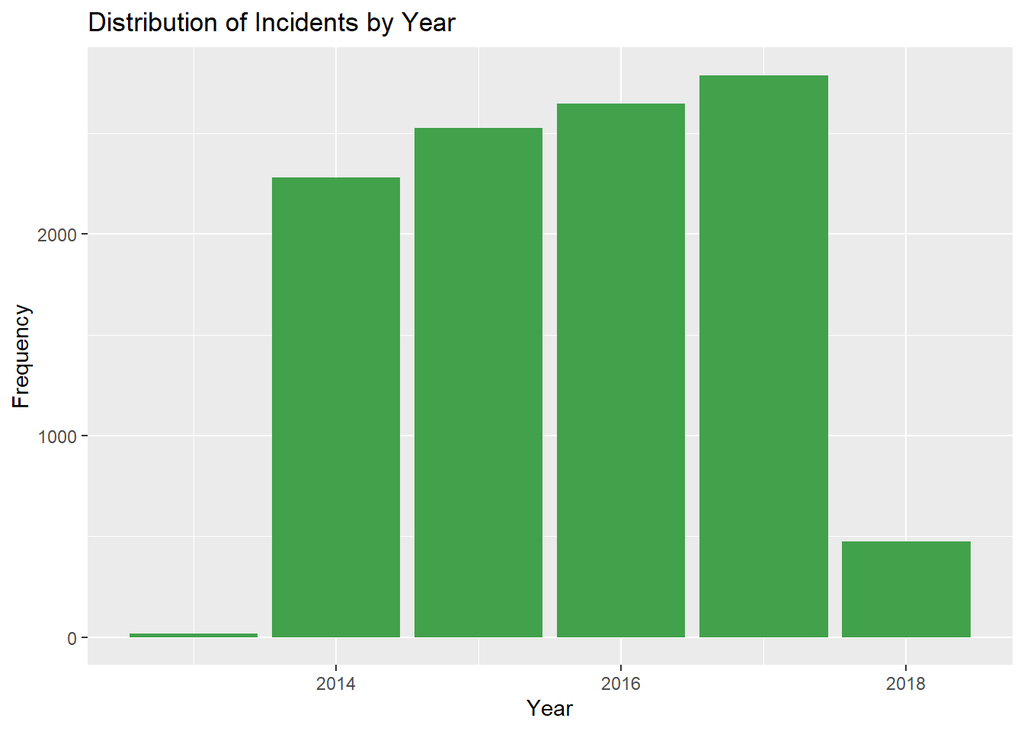

### Distribution of Gun violence incidents over Time (months)

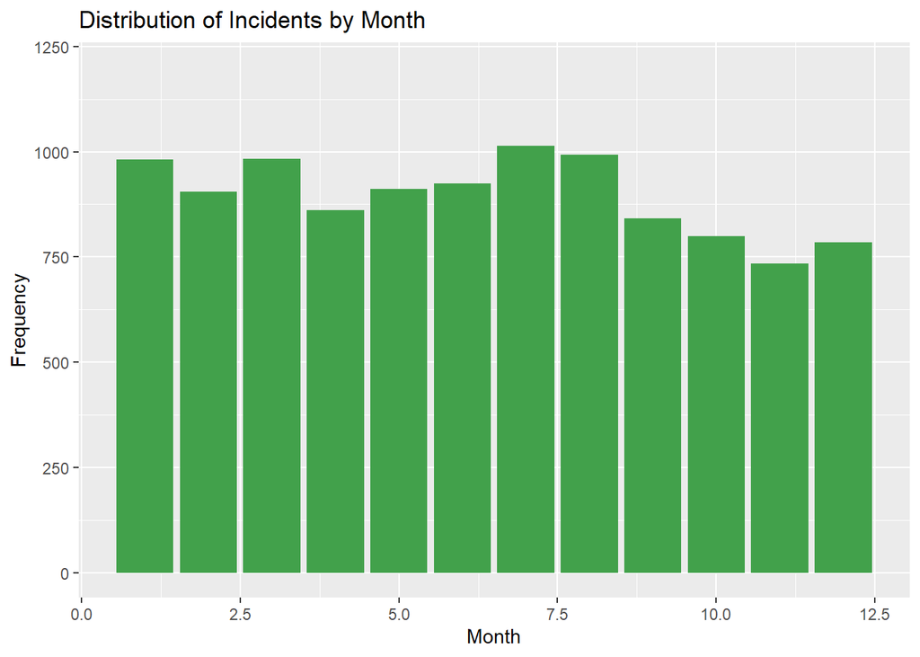

In this histogram, we see the distribution of incidences by month. From this, we can draw the conclusion that the peak months are in the summer (July and August).

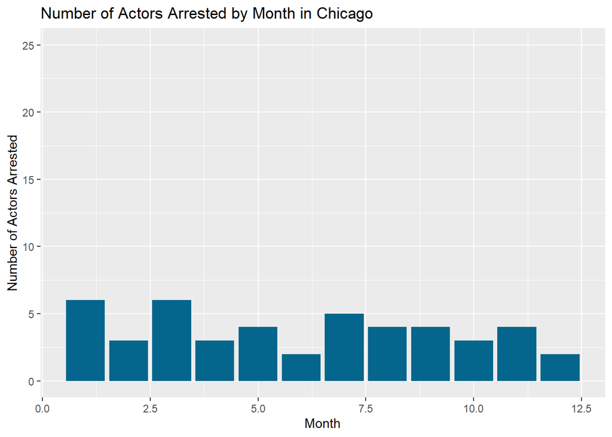

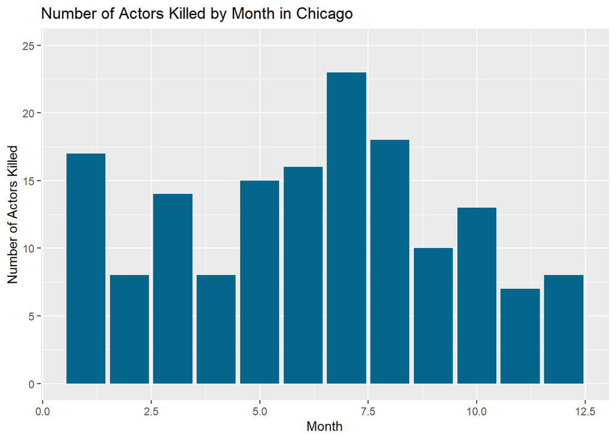

In these Histograms, we can compare the number of actors arrested vs the number of actors killed in Chicago. From this, we can see that unlike most cities, Chicago tends to kill more of the actors on the spot rather than arresting them.

## Predictive Models

### Teen actors in relation to the number killed/injured

```r
#Predictive Models below

#Looking for relationships between the number of teen actors and any of the other variables
fit0 <- lm(n_teen_part~n_killed+n_injured,data=data_clean)
summary(fit0)
```

```
##
## Call:
## lm(formula = n_teen_part ~ n_killed + n_injured, data = data_clean)
##
## Residuals:
##     Min      1Q  Median      3Q     Max
## -0.7153 -0.1827 -0.1073 -0.0973  4.9027
##
## Coefficients:
##             Estimate Std. Error t value Pr(>|t|)
## (Intercept) 0.097279   0.006321  15.390   <2e-16 ***
## n_killed    0.010002   0.007872   1.271    0.204
## n_injured   0.085432   0.005899  14.482   <2e-16 ***
## ---
## Signif. codes:  0 '***' 0.001 '**' 0.01 '*' 0.05 '.' 0.1 ' ' 1
##
## Residual standard error: 0.4518 on 10732 degrees of freedom
## Multiple R-squared:  0.01955,    Adjusted R-squared:  0.01936
## F-statistic:   107 on 2 and 10732 DF,  p-value: < 2.2e-16
```

Results show an Adjusted R-squared of 0.01936, an F-statistic of 107 with a p-value < 2.2e-16 This can be interpreted that the estimate of the mean number of teen actors is 0.097279 when n_killed and n_injured are both 0. The 0.01 estimate for n_killed means that the mean value of teenage actors would be estimated to increase by 0.01 if n_killed increased by 1 unit, holding all other covariates constant. The 0.085432 estimate for n_injured means that the mean value of teenage actors would be estimated to increase by 0.085432 if n_injured increased by 1 unit, holding all other covariates constant.

However, these results show that the number of people killed or injured are not good predictors for estimating the number of teenaged actors in gun violence, as it would be too difficult to predict something as unpredictable as gun violence.

### Number of people killed in relation to the different age groups of actors.

```r
#Looking for relationships between n_killed and the different age groups of participants
fit1 = lm(n_killed~n_adult_part+n_teen_part+n_child_part, data=data_clean)
summary(fit1)
```

```
##
## Call:
## lm(formula = n_killed ~ n_adult_part + n_teen_part + n_child_part,
##     data = data_clean)
##
## Residuals:
##     Min      1Q  Median      3Q     Max
## -0.8584 -0.3906 -0.2828  0.6094  5.3419
##
## Coefficients:
##              Estimate Std. Error t value Pr(>|t|)
## (Intercept)  0.174971   0.011002  15.903  < 2e-16 ***
## n_adult_part 0.107809   0.005782  18.644  < 2e-16 ***
## n_teen_part  0.031719   0.012215   2.597  0.00942 **
## n_child_part 0.155926   0.027671   5.635  1.8e-08 ***
## ---
## Signif. codes:  0 '***' 0.001 '**' 0.01 '*' 0.05 '.' 0.1 ' ' 1
##
## Residual standard error: 0.5591 on 10731 degrees of freedom
## Multiple R-squared:  0.03365,    Adjusted R-squared:  0.03338
## F-statistic: 124.6 on 3 and 10731 DF,  p-value: < 2.2e-16
```

### The number of actors arrested, in relation to the age of the actor, disregarding children.

```r
fit2 = lm(n_part_arrested~n_adult_part+n_teen_part, data=data_clean)
summary(fit2)
```

```
##
## Call:
## lm(formula = n_part_arrested ~ n_adult_part + n_teen_part, data = data_clean)
##
## Residuals:
##     Min      1Q  Median      3Q     Max
## -1.9535 -0.3806 -0.3180  0.6820  4.6820
##
## Coefficients:
##               Estimate Std. Error t value Pr(>|t|)
## (Intercept)  -0.012580   0.014309  -0.879    0.379
## n_adult_part  0.330548   0.007559  43.727   <2e-16 ***
## n_teen_part   0.393224   0.015991  24.591   <2e-16 ***
## ---
## Signif. codes:  0 '***' 0.001 '**' 0.01 '*' 0.05 '.' 0.1 ' ' 1
##
## Residual standard error: 0.7319 on 10732 degrees of freedom
## Multiple R-squared:  0.1644, Adjusted R-squared:  0.1643
## F-statistic:  1056 on 2 and 10732 DF,  p-value: < 2.2e-16
```

### The number of actors killed vs the number of victims killed

```r
fit3 = lm(n_part_killed~n_adult_part+n_teen_part+n_killed, data=data_clean)
summary(fit3)
```

```
##
## Call:
## lm(formula = n_part_killed ~ n_adult_part + n_teen_part + n_killed,
##     data = data_clean)
##
## Residuals:
##      Min       1Q   Median       3Q      Max
## -0.99497 -0.00140 -0.00140  0.00577  0.03545
##
## Coefficients:
##                Estimate Std. Error  t value Pr(>|t|)
## (Intercept)   0.0011519  0.0006837    1.685    0.092 .
## n_adult_part  0.0002468  0.0003622    0.682    0.496
## n_teen_part  -0.0009959  0.0007546   -1.320    0.187
## n_killed      0.9925804  0.0005953 1667.308   <2e-16 ***
## ---
## Signif. codes:  0 '***' 0.001 '**' 0.01 '*' 0.05 '.' 0.1 ' ' 1
##
## Residual standard error: 0.03453 on 10731 degrees of freedom
## Multiple R-squared:  0.9963, Adjusted R-squared:  0.9963
## F-statistic: 9.562e+05 on 3 and 10731 DF,  p-value: < 2.2e-16
```

Results show an Adjusted R-squared of 0.9963, an F-statistic of 9.562e+05 with a p-value < 2.2e-16. This can be interpreted that the estimate of the mean number of actors who’ve died is 0.0011 when n_adult_part, n_teen_part, and n_killed are both 0 (though it’s not 0, it’s very close). This means that 0.0011 of the average actor is dead when the number of teen, adult actors, and number killed are all equal to 0. The 0.0002468 estimate for n_adult_part means that the mean value of actors killed would be estimated to increase by 0.0002468 if n_adult_part increased by 1 unit, holding all other covariates constant. The -0.0009959 estimate for n_teen_part means that the mean value of dead actors would be estimated to increase by -0.0009959 if n_teen_part increased by 1 unit, holding all other covariates constant (this doesn’t make much sense as the opposite of dying is coming back to life, which goes to show that these weren’t good predictors). The 0.9925804 estimate for n_killed means that the mean value of dead actors would increase by almost 1 when n_killed increases by 1 unit, holding all covariates constant. The correlation is strong enough, with an adjusted R-squared of 0.9963, but this dataset never clarified whether or not the actor gets added to this count whenever he/she dies. It seems like that might be the case due to the Adjusted R-squared value being almost 1.

## Reflections

### Aashwin Lamsal

I enjoyed working with all my group mates on this project, the only thing that I would want to change would probably be the data set itself, since this data set didn’t lend itself to predictive analysis very well, being able to predict demographic or geographic changes would have made this project more interesting. My personal contributions to the project were the fitted linear models, and 1-2 of the visualizations of the data. I also worked closely with Eric, especially in the beginning of the project, so we both were bouncing ideas of each other. This work was also placed into the presentation by myself.

### Ethan Wanlass

The part I did in this project was exploration of the number of incidents both in for total number and per capita. I also found and cleaned the population data set from the U.S. Bureau. Furthermore, I put this work into the presentation.

### Eric Friesth

This dataset was a blast to explore and work with regardless of the issues we came across, like not have a strong number of predictors. Even without accurate predictor models, we were still able to pull some interesting insights from this data. My individual contribution included: Some sampling of the original dataset, creating visualizations and drawing insigts from comparing variables like State, City, Number of people killed, Age of Actor, and Number of actors killed/arrested.

## Sources

Heatmap tutorials: https://medium.com/@axelhodler/creating-a-heat-map-from-coordinates-using-r-780db4901075 https://trucvietle.me/r/tutorial/2017/01/18/spatial-heat-map-plotting-using-r.html

Map Visualization: https://stackoverflow.com/questions/23206834/how-to-plot-a-us-state-in-r

Population Dataset: https://www.census.gov/data/tables/time-series/demo/popest/2010s-state-total.html

Pair plot: http://www.sthda.com/english/wiki/scatter-plot-matrices-r-base-graphs

Dataset: https://www.kaggle.com/jameslko/gun-violence-data#gun-violence-data_01-2013_03-2018.csv